# Analisis Dataset Astronomia

## Classification of Stars, Galaxies and Quasars

https://www.sdss.org/dr17/

http://skyserver.sdss.org/dr17/SearchTools/sql

```python
# Import library
import seaborn as sns
import matplotlib.pyplot as plt
import numpy as np
import pandas as pd
from scipy.stats import normaltest
from scipy.stats import zscore
from PIL import Image
pd.options.display.max_columns = None
```

## Analisis general de datos

```python
# Load Dataset
df=pd.read_csv('Skyserver_SQL1_5_2022 11_26_53 PM.csv', skiprows=5, low_memory=False)
df.head(3)
```

|  | objid | ra | dec | u | g | r | i | z | run | rerun | camcol | field | specobjid | class | redshift | plate | mjd | fiberid |
| --- | --- | --- | --- | --- | --- | --- | --- | --- | --- | --- | --- | --- | --- | --- | --- | --- | --- | --- |
| 0 | 1237678598097404025 | 15.851405 | 3.191167 | 18.05289 | 17.09906 | 16.73790 | 16.60352 | 16.56954 | 7712.0 | 301.0 | 5.0 | 435.0 | 9858503408339933184 | STAR | -0.000662 | 8756.0 | 57687.0 | 450.0 |
| 1 | 1237678598076366970 | 327.767460 | 2.724566 | 17.89419 | 17.00824 | 16.73965 | 16.65107 | 16.61760 | 7712.0 | 301.0 | 5.0 | 114.0 | 12755446354945529856 | STAR | -0.000868 | 11329.0 | 58426.0 | 459.0 |
| 2 | 1237678858476388409 | 11.094705 | 11.901323 | 19.29361 | 18.35319 | 18.02509 | 17.88756 | 17.84319 | 7773.0 | 301.0 | 2.0 | 383.0 | 6986389895423219712 | STAR | -0.000979 | 6205.0 | 56187.0 | 658.0 |

```python
df.info()
```

```
<class 'pandas.core.frame.DataFrame'>
RangeIndex: 100003 entries, 0 to 100002
Data columns (total 18 columns):
 #   Column     Non-Null Count   Dtype
---  ------     --------------   -----
 0   objid      100003 non-null  object
 1   ra         100000 non-null  float64
 2   dec        100000 non-null  float64
 3   u          100000 non-null  float64
 4   g          100000 non-null  float64
 5   r          100000 non-null  float64
 6   i          100000 non-null  float64
 7   z          100000 non-null  float64
 8   run        100000 non-null  float64
 9   rerun      100000 non-null  float64
 10  camcol     100000 non-null  float64
 11  field      100000 non-null  float64
 12  specobjid  100003 non-null  object
 13  class      100000 non-null  object
 14  redshift   100000 non-null  float64
 15  plate      100000 non-null  float64
 16  mjd        100000 non-null  float64
 17  fiberid    100000 non-null  float64
dtypes: float64(15), object(3)
memory usage: 13.7+ MB
```

```python
# Obtener la cantidad de datos segun clase
df.groupby(by='class').size()
```

```
class
GALAXY    51646
QSO       10508
STAR      37846
dtype: int64
```

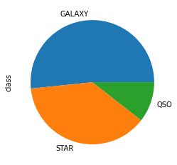

```python
df['class'].value_counts().plot.pie(y='class');
```

- la menor cantidad de datos corresponde a QSO (quasars) y la mayor a Galaxy

## Estructura de Datos

- objid : SDSS identificador compuesto de skyVersion,rerun,run,camcol,field,obj
- ra, dec : Right ascension (ra) and Declination (dec). Especifica la direccion de un punto de la esfera celeste en el sistema de coordenadas ecuatoriales
- u,g, r, i, z : Bandas espectometricas
- run : Identifica el scan
- rerun : Reproceso de imaging run
- camcol : identica el scanline con run
- field : Field number
- specobjid :
- class : galaxy, star or quasar object
- redshift : Valor observedo de Redshift
- plate : Each spectroscopic exposure employs a large, thin, circular metal plate that positions optical fibers
- mjd : Modified Julian Date, i.e. the date at which the data were taken
- fiberid : fiber ID

## Analisis de datos nulos

```python
# Verificar valores nulos
df.isnull().sum()
```

```
objid        0
ra           3
dec          3
u            3
g            3
r            3
i            3
z            3
run          3
rerun        3
camcol       3
field        3
specobjid    0
class        3
redshift     3
plate        3
mjd          3
fiberid      3
dtype: int64
```

```python
# Observar variable con valores nulos
df[df["class"].isnull()]
```

|  | objid | ra | dec | u | g | r | i | z | run | rerun | camcol | field | specobjid | class | redshift | plate | mjd | fiberid |
| --- | --- | --- | --- | --- | --- | --- | --- | --- | --- | --- | --- | --- | --- | --- | --- | --- | --- | --- |
| 100000 | </div> | NaN | NaN | NaN | NaN | NaN | NaN | NaN | NaN | NaN | NaN | NaN |  | NaN | NaN | NaN | NaN | NaN |
| 100001 | </div> | NaN | NaN | NaN | NaN | NaN | NaN | NaN | NaN | NaN | NaN | NaN |  | NaN | NaN | NaN | NaN | NaN |
| 100002 | </div> | NaN | NaN | NaN | NaN | NaN | NaN | NaN | NaN | NaN | NaN | NaN |  | NaN | NaN | NaN | NaN | NaN |

- Los valores nulos solo corresponden al formato en csv, se eliminaran.

```python
df.dropna(inplace=True)
df[df["class"].isnull()]
#df.info()
```

|  | objid | ra | dec | u | g | r | i | z | run | rerun | camcol | field | specobjid | class | redshift | plate | mjd | fiberid |
| --- | --- | --- | --- | --- | --- | --- | --- | --- | --- | --- | --- | --- | --- | --- | --- | --- | --- | --- |

## Analisis de datos estadisticos

```python
df.describe()
```

|  | ra | dec | u | g | r | i | z | run | rerun | camcol | field | redshift | plate | mjd | fiberid |
| --- | --- | --- | --- | --- | --- | --- | --- | --- | --- | --- | --- | --- | --- | --- | --- |
| count | 100000.000000 | 100000.000000 | 100000.000000 | 100000.000000 | 100000.000000 | 100000.000000 | 100000.000000 | 100000.000000 | 100000.0 | 100000.000000 | 100000.000000 | 100000.000000 | 100000.00000 | 100000.000000 | 100000.000000 |
| mean | 177.915604 | 25.050633 | 18.638953 | 17.406257 | 16.879252 | 16.622287 | 16.462865 | 3974.396910 | 301.0 | 3.280110 | 186.827890 | 0.169856 | 2583.93894 | 53909.522880 | 341.614400 |
| std | 78.002885 | 20.512636 | 0.829678 | 0.982824 | 1.130434 | 1.206917 | 1.280508 | 1687.041034 | 0.0 | 1.616829 | 141.194237 | 0.437127 | 2216.34789 | 1548.199211 | 216.889477 |
| min | 0.013890 | -19.364576 | 10.611810 | 9.668339 | 9.005167 | 8.896696 | 8.947795 | 109.000000 | 301.0 | 1.000000 | 11.000000 | -0.004136 | 266.00000 | 51608.000000 | 1.000000 |
| 25% | 136.793076 | 6.798342 | 18.215430 | 16.852100 | 16.193920 | 15.861390 | 15.614970 | 2826.000000 | 301.0 | 2.000000 | 85.000000 | 0.000003 | 1186.00000 | 52734.000000 | 160.000000 |
| 50% | 180.707467 | 23.988488 | 18.873725 | 17.514180 | 16.888850 | 16.596690 | 16.424970 | 3900.000000 | 301.0 | 3.000000 | 152.000000 | 0.046361 | 2057.00000 | 53712.000000 | 327.000000 |
| 75% | 224.657528 | 40.307321 | 19.272690 | 18.053048 | 17.581523 | 17.340332 | 17.227990 | 5060.000000 | 301.0 | 5.000000 | 248.000000 | 0.095396 | 2907.00000 | 54585.000000 | 502.000000 |
| max | 359.999615 | 84.490494 | 19.599990 | 19.996050 | 31.990100 | 32.141470 | 29.383740 | 8162.000000 | 301.0 | 6.000000 | 982.000000 | 7.011245 | 12547.00000 | 58932.000000 | 1000.000000 |

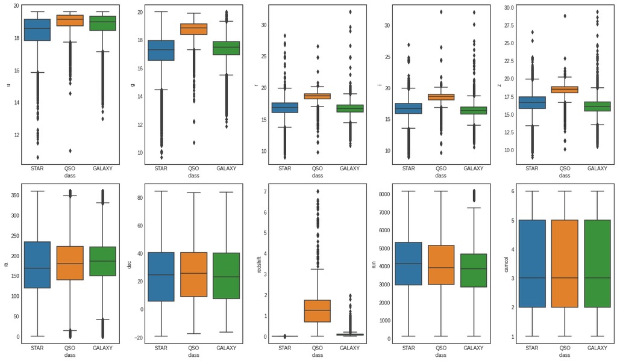

```python
# BoxPlot - valores estadisticos y datos atipicos
cols = ['u', 'g', 'r', 'i', 'z', 'ra', 'dec', 'redshift', 'run', 'camcol']
plt.figure(figsize = (17, 10));
plt.style.use('seaborn-white')

i=1
for cat in cols:
    ax=plt.subplot(2,5,i)
    i+=1
    sns.boxplot(x='class',y=cat,data=df);
    plt.tight_layout();
```

- En este caso (dataset astronomico) es complicado determinar valores atipicos, ya que sus valores corresponden a su ubicacion, brillo y tamaño en el espacio, por lo cual, estos valores representan interes de estudio astronomico.
- Se analizaran los quantiles Q1 y Q3 para tener una mejor idea del caso

```python
# Funcion de calculo quantiles, Q1, Q3 y valores limites para cada clase
def quantilQ1Q3(data):
    Q1 = data.quantile(q=0.25)
    Q3 = data.quantile(q=0.75)
    IQR=Q3-Q1
    minlimit= Q1 - 1.5 * IQR
    maxlimit= Q3 + 1.5 * IQR
    return minlimit, maxlimit
```

```python
# Calculo quantiles, Q1, Q3 y valores limites para cada clase. Creacion de dataFrame valores limites
def getLimit(astro):
    cols = ['u', 'g', 'r', 'i', 'z', 'ra', 'dec', 'redshift']
    temp1=pd.DataFrame(['min', 'max'], columns=["minmax"])
    data2 =df[df['class']==astro][cols].copy()
    ast=pd.DataFrame([astro, astro], columns=["class"])
    qlimit=pd.concat([ast,temp1], axis=1)
    for var in cols:
        rows=quantilQ1Q3(data2[var])
        temp2=pd.DataFrame(rows, columns=[var])
        qlimit=pd.concat([qlimit, temp2], axis=1)
    return qlimit

qlimitStar=getLimit('STAR')
qlimitQSO=getLimit('QSO')
qlimitGalaxy=getLimit('GALAXY')
qlimit=pd.concat([qlimitStar, qlimitQSO, qlimitGalaxy], keys=["STAR", "QSO", "Galaxy"])

qlimit
```

|  |  | class | minmax | u | g | r | i | z | ra | dec | redshift |
| --- | --- | --- | --- | --- | --- | --- | --- | --- | --- | --- | --- |
| STAR | 0 | STAR | min | 15.835332 | 14.444850 | 13.744011 | 13.473628 | 13.304760 | -52.514189 | -46.561835 | -0.000844 |
|  | 1 | STAR | max | 21.106093 | 20.067710 | 19.905761 | 19.873287 | 19.906580 | 404.967691 | 92.763547 | 0.000629 |
| QSO | 0 | QSO | min | 17.706673 | 17.279999 | 17.006667 | 16.826184 | 16.603966 | 14.365460 | -38.657440 | -0.865306 |
|  | 1 | QSO | max | 20.395632 | 20.256749 | 20.189808 | 20.141694 | 20.208996 | 347.738555 | 88.009638 | 3.287806 |
| Galaxy | 0 | GALAXY | min | 17.114539 | 15.493471 | 14.445373 | 13.940648 | 13.463773 | 40.868827 | -41.759733 | -0.031106 |
|  | 1 | GALAXY | max | 20.625689 | 19.309881 | 18.972412 | 18.723868 | 18.678812 | 330.280684 | 89.165794 | 0.179951 |

- Considerando que utilizar el metodo de quantiles para determinar outliers se ocupa sobre distribuciones normales, realizaremos un test de normalidad

### Test de Normalidad

```python
# test de normalidad 'u', 'g', 'r', 'i', 'z', 'ra', 'dec', 'redshift'
cols = ['u', 'g', 'r', 'i', 'z', 'ra', 'dec', 'redshift']
for astro in df['class'].unique().tolist():
    data2 =df[df['class']==astro][cols].copy()
    for var in cols:
        stat, p = normaltest(data2[var])
        print(astro, 'var=', var)
        # interpretacion
        alpha = 1e-3
        if p < alpha:
            print('Statistics = %.3f, p = %g,  does NOT look like a normal distribution, H0 can be rejected' % (stat, p))
        else:
            print('Statistics = %.3f, p = %g,  looks like a normal distribution, H0 cannot be rejected' % (stat, p))
```

```
STAR var= u
Statistics = 5753.981, p = 0,  does NOT look like a normal distribution, H0 can be rejected
STAR var= g
Statistics = 5045.355, p = 0,  does NOT look like a normal distribution, H0 can be rejected
STAR var= r
Statistics = 3213.200, p = 0,  does NOT look like a normal distribution, H0 can be rejected
STAR var= i
Statistics = 2098.845, p = 0,  does NOT look like a normal distribution, H0 can be rejected
STAR var= z
Statistics = 1289.172, p = 1.14764e-280,  does NOT look like a normal distribution, H0 can be rejected
STAR var= ra
Statistics = 909.439, p = 3.29563e-198,  does NOT look like a normal distribution, H0 can be rejected
STAR var= dec
Statistics = 4024.295, p = 0,  does NOT look like a normal distribution, H0 can be rejected
STAR var= redshift
Statistics = 10866.567, p = 0,  does NOT look like a normal distribution, H0 can be rejected
QSO var= u
Statistics = 4547.118, p = 0,  does NOT look like a normal distribution, H0 can be rejected
QSO var= g
Statistics = 4611.582, p = 0,  does NOT look like a normal distribution, H0 can be rejected
QSO var= r
Statistics = 4281.235, p = 0,  does NOT look like a normal distribution, H0 can be rejected
QSO var= i
Statistics = 3982.199, p = 0,  does NOT look like a normal distribution, H0 can be rejected
QSO var= z
Statistics = 3901.494, p = 0,  does NOT look like a normal distribution, H0 can be rejected
QSO var= ra
Statistics = 152.062, p = 9.55171e-34,  does NOT look like a normal distribution, H0 can be rejected
QSO var= dec
Statistics = 2015.805, p = 0,  does NOT look like a normal distribution, H0 can be rejected
QSO var= redshift
Statistics = 2433.376, p = 0,  does NOT look like a normal distribution, H0 can be rejected
GALAXY var= u
Statistics = 15793.290, p = 0,  does NOT look like a normal distribution, H0 can be rejected
GALAXY var= g
Statistics = 11338.554, p = 0,  does NOT look like a normal distribution, H0 can be rejected
GALAXY var= r
Statistics = 8393.146, p = 0,  does NOT look like a normal distribution, H0 can be rejected
GALAXY var= i
Statistics = 7171.020, p = 0,  does NOT look like a normal distribution, H0 can be rejected
GALAXY var= z
Statistics = 5068.917, p = 0,  does NOT look like a normal distribution, H0 can be rejected
GALAXY var= ra
Statistics = 2597.617, p = 0,  does NOT look like a normal distribution, H0 can be rejected
GALAXY var= dec
Statistics = 13860.117, p = 0,  does NOT look like a normal distribution, H0 can be rejected
GALAXY var= redshift
Statistics = 72247.136, p = 0,  does NOT look like a normal distribution, H0 can be rejected
```

- Ninguna de la variables muestra una distribucion normal segun el test aplicado, por lo tanto no podemos eliminar outliers con el metodo de quantiles
- Los histogramas a continuacionnos graficaran como lucen las distribuciones de las variables

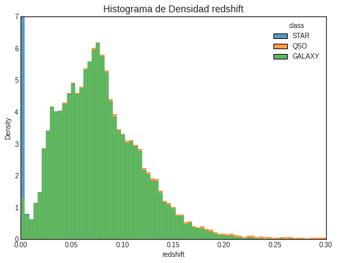

```python
# Histograma redshift
plt.figure(figsize=(8, 6))
sns.histplot(data=df, x='redshift', legend=True, hue='class', multiple='stack', stat='density');
plt.xlim(0, 0.3)
plt.ylim(0, 7)
plt.title('Histograma de Densidad redshift', size=14);
```

- El Redshift o Desplazamiento al rojo. Un mecanismo físico que puede causar corrimiento al rojo, es debido a la expansión métrica del espacio. El corrimiento al rojo espectral de galaxias distantes, quasares y nubes gaseosas intergalácticas se incrementa proporcionalmente con su distancia al observador.
- Se observa que la mayoría de objetos están contenidos hasta un redshift de aproximadamente 0.20, siendo el rango de valores entre 0 y 7.
- Los datos de redshift para Star, se encuentran proximos a cero
- La forma de distribucion para QSO y Galaxy, se asemeja a una distribucion gamma.

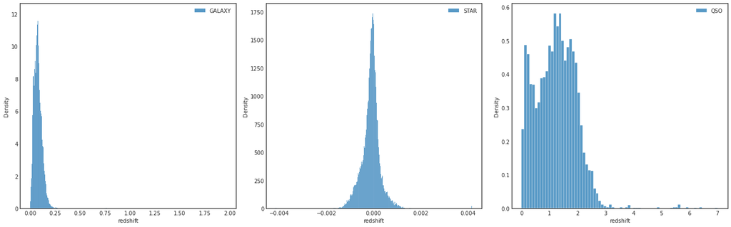

```python
plt.figure(figsize=(19,6))
sns.set_style("ticks")
plt.subplot(1, 3, 1)
sns.histplot(df[df['class']=='GALAXY']['redshift'], label = 'GALAXY', stat='density')
plt.legend()
plt.subplot(1, 3, 2)
sns.histplot(df[df['class']=='STAR']['redshift'], label = 'STAR', stat='density')
plt.legend()
plt.subplot(1, 3, 3)
sns.histplot(df[df['class']=='QSO']['redshift'], label = 'QSO', stat='density')
plt.legend()
plt.tight_layout()
```

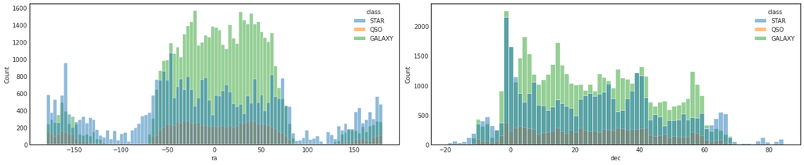

```python
# Grafico de frecuencias de ra y dec segun tipo de astro
plt.figure(figsize=(19,4))
sns.set_style("ticks")
plt.subplot(1, 2, 1)
sns.histplot(data=df, x=df['ra']-180, legend=True, hue='class', stat='count'); # ra tiene rango 0 a 360 (-180 a 180)
plt.subplot(1, 2, 2)
sns.histplot(data=df, x='dec', legend=True, hue='class', stat='count'); # dec tiene rango -90 a 90
plt.tight_layout()
```

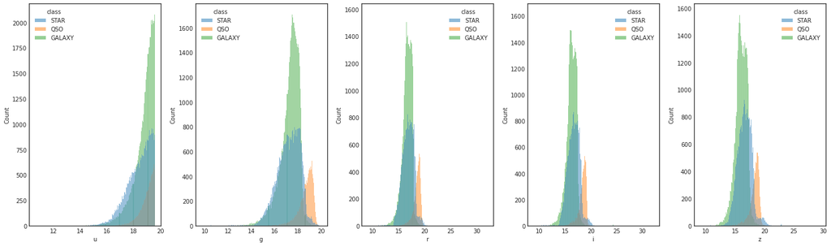

```python
# Grafico de frecuencias de STAR, QSO y Galaxia segun las variables espectrales u, g, r, i, z
cols = ['u', 'g', 'r', 'i', 'z']
plt.figure(figsize=(20,6))
sns.set_style("ticks")
j=1
for var in cols:
    plt.subplot(1, 5, j)
    sns.histplot(data=df, x=var, legend=True, hue='class');
    j+=1
plt.tight_layout()
```

- las distribucion para las variables espectrales u, g, r, i, z, podrían ser del tipo T de Student (mas adelante se realizara el grafico inverso, es decir para STAR, QSO y Galaxy con los valores de frecuencia de las variables espectrales

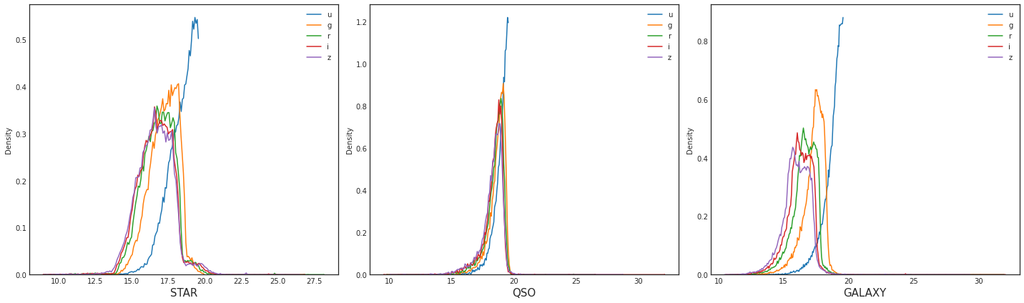

```python
# Grafico de frecuencias de u, g, r, i, z, segun tipo de astro
cols = ['u', 'g', 'r', 'i', 'z']
plt.figure(figsize=(20,6));
j=1
for astro in df['class'].unique().tolist():
    plt.subplot(1, 3, j)
    i=0
    for col in cols:
        data2=df[df['class']==astro]
        sns.histplot(data=data2,x=data2[col], label =col, legend=True, kde=False, color=sns.color_palette()[i],
                    fill=False, element="poly", stat="density")
        plt.xlabel(astro, size=15)
        i+=1
    j+=1
    plt.legend()
    plt.tight_layout();
```

- Los datos fueron obtenidos con un filtro en 'u' entre 0 y 19.6, y 'g' entre 0 y 20
- En este grafico de frecuencias, separados por clase, se puede observar con mayor facilidad que las distribuciones para las clases STAR y Galaxy, se asemejan a la distribucion normales, excepto para la clase QSO, que sería T Students

### Normalizacion de variables

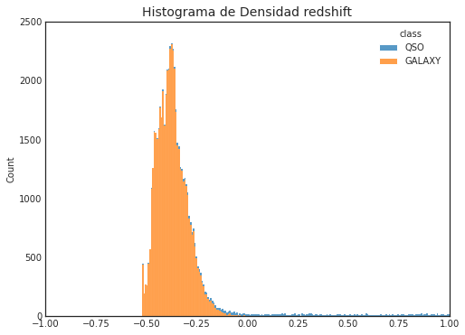

```python
# Histograma redshift clases QSO y Galaxy
plt.figure(figsize=(8, 6))
df2=df[df['class']!='STAR'].copy()
sns.histplot(data=df2, x=zscore(df2['redshift']), legend=True, hue='class', multiple='stack');
plt.xlim(-1, 1)
plt.ylim(0, 2500)
plt.title('Histograma de Densidad redshift', size=14);
```

- No se utilizó la variable STAR, ya que se observó en el grafico anterio que sus valores estan en torno a cero.
- Como ya se habia dicho, esta distribucion no corresponde a una normal, por tanto la funcion de normalizacion zscore, no es aplicable. Se observa que los valores centrales se encuentran en torno a -0.35.
- Se aplicara mas adelante la funcion ´tanh´ para obtener una distribucion normal de estos valores

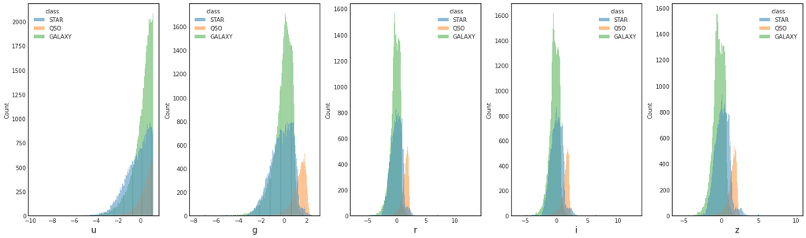

```python
# Grafico de frecuencias de STAR, QSO y Galaxia segun las variables espectrales u, g, r, i, z utilizando zscore
cols = ['u', 'g', 'r', 'i', 'z']
plt.figure(figsize=(20,6))
sns.set_style("ticks")
j=1
for var in cols:
    plt.subplot(1, 5, j)
    sns.histplot(data=df, x=zscore(df[var]), legend=True, hue='class');
    j+=1
    plt.xlabel(var, size=15)
plt.tight_layout()
```

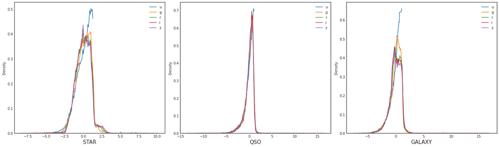

```python
# Grafico de frecuencias de u, g, r, i, z, segun tipo de astro utilizando zscore
cols = ['u', 'g', 'r', 'i', 'z']
plt.figure(figsize=(20,6));
j=1
for astro in df['class'].unique().tolist():
    plt.subplot(1, 3, j)
    i=0
    for col in cols:
        data2=df[df['class']==astro]
        sns.histplot(data=data2,x=zscore(data2[col]), label =col, legend=True, kde=False, color=sns.color_palette()[i],
                    fill=False, element="poly", stat="density")
        plt.xlabel(astro, size=15)
        i+=1
    j+=1
    plt.legend()
    plt.tight_layout();
```

- Se observa de los graficos que la medida central esta en el valor cero para todas las variables (normalizando así los datos)

### Normalizacion variable redshift

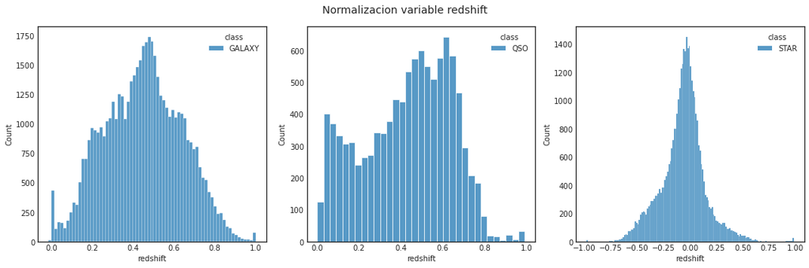

```python
# Histograma redshift clases QSO y Galaxy
pg=0.15
pq=2.5
ps=0.0017
plt.figure(figsize=(15, 5))
plt.suptitle('Normalizacion variable redshift', size=14);
plt.subplot(1, 3, 1)

df2=df[(df['class']=='GALAXY')].copy()
sns.histplot(data=df2, x=np.tanh((df2['redshift'])/pg), legend=True, hue='class', multiple='stack');
plt.subplot(1, 3, 2)
df2=df[(df['class']=='QSO')].copy()
sns.histplot(data=df2, x=np.tanh((df2['redshift'])/pq), legend=True, hue='class', multiple='stack');
plt.subplot(1, 3, 3)
df2=df[(df['class']=='STAR')].copy()
sns.histplot(data=df2, x=np.tanh((df2['redshift'])/ps), legend=True, hue='class', multiple='stack');
plt.tight_layout();
```

### Normalizacion variable redshift y standarizacion zscore

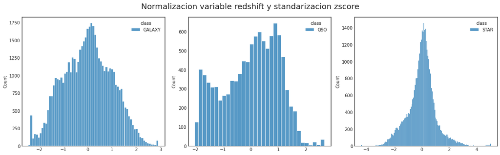

```python
# Histograma redshift clases QSO y Galaxy
pg=0.15
pq=2.5
ps=0.0017
plt.figure(figsize=(16, 5))
plt.suptitle('Normalizacion variable redshift y standarizacion zscore', size=18);
plt.subplot(1, 3, 1)

df2=df[(df['class']=='GALAXY')].copy()
sns.histplot(data=df2, x=zscore(np.tanh((df2['redshift'])/pg)), legend=True, hue='class', multiple='stack');
plt.subplot(1, 3, 2)
df2=df[(df['class']=='QSO')].copy()
sns.histplot(data=df2, x=zscore(np.tanh((df2['redshift'])/pq)), legend=True, hue='class', multiple='stack');
plt.subplot(1, 3, 3)
df2=df[(df['class']=='STAR')].copy()
sns.histplot(data=df2, x=zscore(np.tanh((df2['redshift'])/ps)), legend=True, hue='class', multiple='stack');
plt.tight_layout();
```

- Se puede observar que luego de los procesos normalizacion y standarizacion zscore las distribuciones (excepto la clase QSO) se asemejan a normales y centradas en cero

### Matriz de corelacion para cada clase

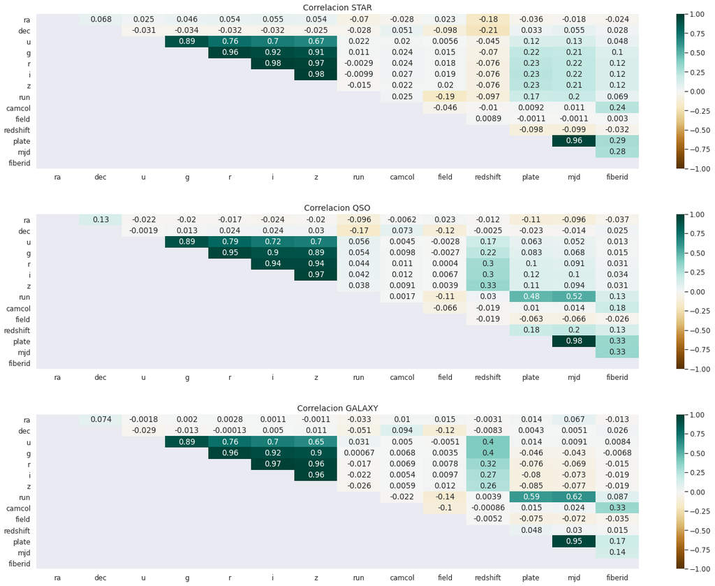

```python
#cols = ['u', 'g', 'r', 'i', 'z']
sns.set(font_scale=1.1)
fig, axs = plt.subplots(3, 1, sharex = False, figsize=(20,15))
i=0
for astro in df['class'].unique().tolist():
    axs[i].set_title('Correlacion {}'.format(astro), size=14)
    data2=df[df['class']==astro].drop('rerun', axis=1, inplace=False)
    corr = data2.corr()
    mask = np.tril(np.ones_like(corr, dtype=np.bool))
    sns.heatmap(corr, annot=True, cmap='BrBG', mask=mask, ax=axs[i], vmin=-1, vmax=1);
    #sns.heatmap(corr, annot=True, cmap='BrBG', mask=None, ax=axs[i], vmin=-1, vmax=1);
    i+=1
    plt.tight_layout(pad=3);
```

- En general las correlaciones son similares, se observan alguna diferencias en los parametros espectrales (u,g,r,i,z), sin embargo a simple vista no son significativas

### Matriz de corelacion utilizando las clases

- Como la clase es un valor categorico, lo convertiremos a numerico usando la funcion one-hot encoder

```python
# one-hot in class
#df_hot=pd.get_dummies(df, columns=['class'], drop_first=False).drop('rerun', axis=1, inplace=False)
df_hot = pd.concat([df.drop('rerun', axis=1, inplace=False), pd.get_dummies(df['class'],drop_first=False)],axis=1)
df_hot.head()
```

|  | objid | ra | dec | u | g | r | i | z | run | camcol | field | specobjid | class | redshift | plate | mjd | fiberid | GALAXY | QSO | STAR |
| --- | --- | --- | --- | --- | --- | --- | --- | --- | --- | --- | --- | --- | --- | --- | --- | --- | --- | --- | --- | --- |
| 0 | 1237678598097404025 | 15.851405 | 3.191167 | 18.05289 | 17.09906 | 16.73790 | 16.60352 | 16.56954 | 7712.0 | 5.0 | 435.0 | 9858503408339933184 | STAR | -0.000662 | 8756.0 | 57687.0 | 450.0 | 0 | 0 | 1 |
| 1 | 1237678598076366970 | 327.767460 | 2.724566 | 17.89419 | 17.00824 | 16.73965 | 16.65107 | 16.61760 | 7712.0 | 5.0 | 114.0 | 12755446354945529856 | STAR | -0.000868 | 11329.0 | 58426.0 | 459.0 | 0 | 0 | 1 |
| 2 | 1237678858476388409 | 11.094705 | 11.901323 | 19.29361 | 18.35319 | 18.02509 | 17.88756 | 17.84319 | 7773.0 | 2.0 | 383.0 | 6986389895423219712 | STAR | -0.000979 | 6205.0 | 56187.0 | 658.0 | 0 | 0 | 1 |
| 3 | 1237678858480320652 | 20.370838 | 11.450133 | 18.48399 | 17.59546 | 17.25394 | 17.03100 | 16.70826 | 7773.0 | 2.0 | 443.0 | 12468279482455971840 | QSO | 2.492275 | 11074.0 | 58488.0 | 232.0 | 0 | 1 | 0 |
| 4 | 1237667538008080417 | 151.743169 | 21.340520 | 18.54051 | 17.60909 | 17.25403 | 17.13204 | 17.06285 | 5137.0 | 4.0 | 257.0 | 10784128373875824640 | STAR | 0.000002 | 9578.0 | 57817.0 | 942.0 | 0 | 0 | 1 |

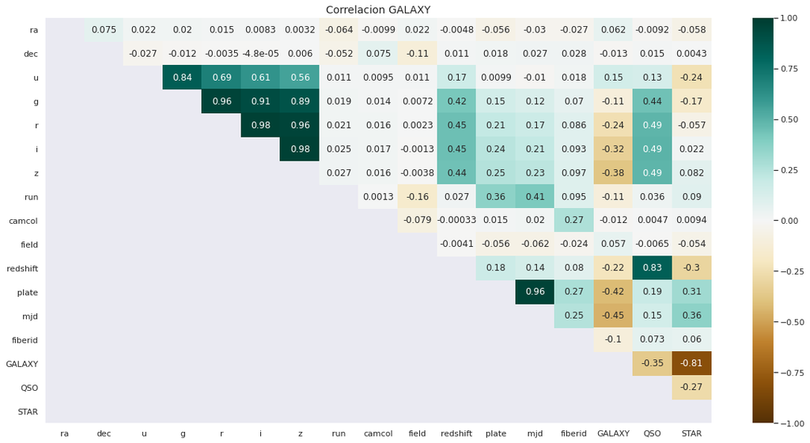

```python
plt.figure(figsize=(20,10))
sns.set(font_scale=1)
corr = df_hot.corr()
plt.title('Correlacion GALAXY', size=14);
mask = np.tril(np.ones_like(corr, dtype=np.bool))
sns.heatmap(corr, annot=True, cmap='BrBG', vmin=-1, vmax=1, mask=mask);
```

- Se que los valores de luminosidad (u,g,r,i,z) estan fuertemente correlacionados (como era de esperar)
- Existe fuerte correlacion entre galaxia y estrella, no asi con quasar
- Los quasars estan fuertemente correlacionados con la variable redshift

## Posicionamiento de datos, variables ra y dec

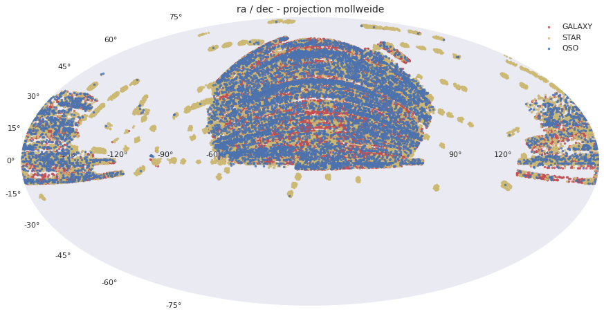

```python
fig = plt.figure(figsize=(15,10))
ax = fig.add_subplot(111, projection='mollweide') # projeccion de -180 a 180
ax.scatter(np.radians(df[df['class']=='GALAXY']['ra']-180), np.radians(df[df['class']=='GALAXY']['dec']), s=6, c='r', alpha=0.8, label='GALAXY')
ax.scatter(np.radians(df[df['class']=='STAR']['ra']-180), np.radians(df[df['class']=='STAR']['dec']), s=6, c='y', alpha=0.8, label='STAR')
ax.scatter(np.radians(df[df['class']=='QSO']['ra']-180), np.radians(df[df['class']=='QSO']['dec']), s=6, c='b', alpha=0.8, label='QSO')
ax.legend()
ax.set_title('ra / dec - projection mollweide', size=14)
plt.grid(linestyle='dotted', color='grey')
plt.show()
```

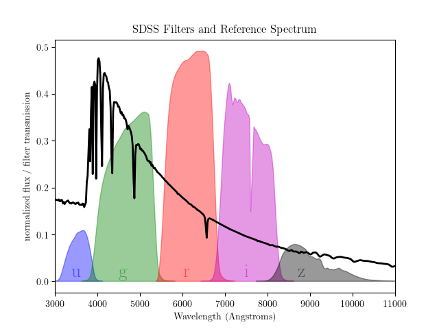

```python
# Rango espectral referencia SDSS
im = Image.open('sdss_reference.png')
im
```

```python
# Rango espectral promedio
df.groupby(by='class').mean()[['u', 'g', 'r', 'i', 'z']]
```

| class | u | g | r | i | z |
| --- | --- | --- | --- | --- | --- |
| GALAXY | 18.760392 | 17.304633 | 16.611957 | 16.243963 | 15.994227 |
| QSO | 18.963776 | 18.678168 | 18.492484 | 18.360395 | 18.281105 |
| STAR | 18.383044 | 17.191789 | 16.796094 | 16.655974 | 16.597549 |

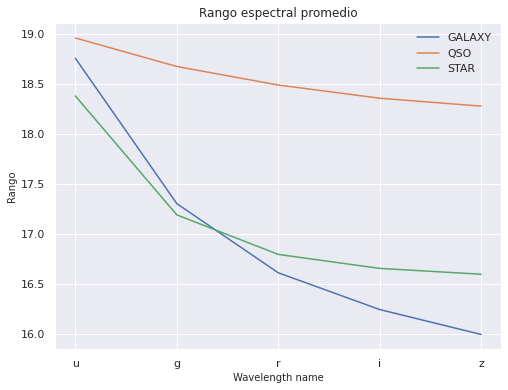

```python
plt.figure(figsize=(8, 6))
df2=df.groupby(by='class').mean()[['u', 'g', 'r', 'i', 'z']]
plt.title('Rango espectral promedio', size=12);
plt.ylabel('Rango', size=10)
plt.xlabel('Wavelength name', size=10)
for astro in df2.index:
    sns.lineplot(data=df2.loc[astro], legend=True, label=astro); #, hue='class'
    plt.legend()
```

- los valores espectrales no han sido corregidos, por lo que no son aun comparables con la imagen anterior